# MT is Better than AT for Fuel Efficiency (MPG)

### Linear Regression Model Selection

In this sub-part, we will firstly fit the linear models for `mpg` against all other variables, and use the `step` function to delect some variable to find the optimal linear models.

```r
fit.whole <- lm(mpg ~ ., data = mtcars.fact)
fit.optimal <- step(fit.whole, direction = 'both')
```

```r
print(fit.optimal$call)
```

```
## lm(formula = mpg ~ cyl + hp + wt + am, data = mtcars.fact)
```

As is printed above, the optimal linear models includes the numeric argument `hp`, `wt`, and factoral argument `cyl`, `am`.  
Now we will test different models with some combinations of arguments `hp` `wt` `cyl` and `am`. We will use the $R^2$ criterion.

```r
fit.hpwt <- lm(mpg ~ hp + wt, data = mtcars.fact)
fit.hpwt.cyl <- lm(mpg ~ hp + wt + cyl, data = mtcars.fact)
```

**Table 3. The $R^2$ of Each Linear Models**

```
##            hp + wt      hp + wt + cyl hp + wt + cyl + am
##             0.8148             0.8361             0.8401
```

According to the table, the linear model fitted with the variable `am` can fit better, compared to several other models. Thus `am` has the influential effects towards the `mpg`.

## Appendix

### Figure 1 from the Part 2

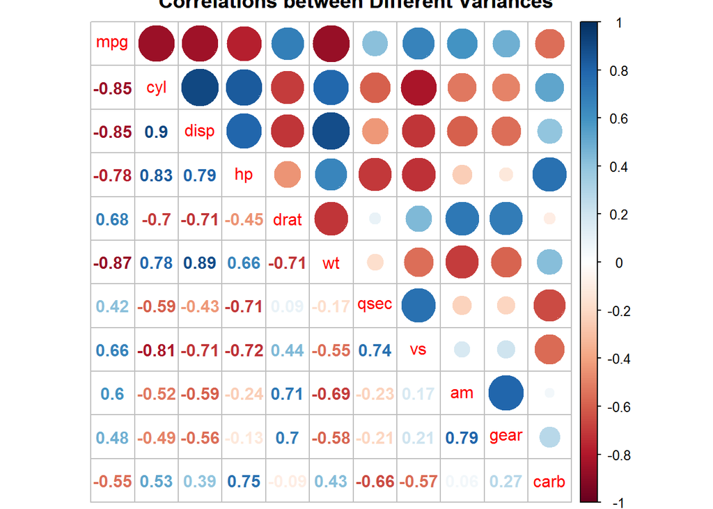

```r
M <- cor(mtcars)
corrplot.mixed(M, lower = "number", upper = "circle", title = "Correlations between Different Variances")
```